# Effect of Game Theoretical Margin on Game Success

**Dave Porter, September 2019**

*The main purpose of this document is to provide an example of my skills in:*

- *Python coding,*
- *Data manipulation,*
- *Data analysis,*
- *Statistical inference,*
- *Linear regression,*
- *Technical report writitng.*

*This work was subcontracted to me via 4ThePlayer for a wider business analysis project contracted by their business partner. At the request of the business partner these data have been anonymised. Therefore some of the analysis methods and conclusions presented here will differ from the original study.*

*For better readability and overall flow of the report, the original submitted to the business partner does not contain code chunks and some sections appear in the Appendix instead of the main body of the report.*

*The intended audience of the original report has a good understanding of probability and statistics so some technical terms are used throughout. This also applies to the intended audience of this modified report.*

## Executive Summary

The objective of this report is to determine whether theoretical margin can be used to predict how successful an online slot game will be. The theoretical margin is the fraction of wagers placed by the player that will generate revenue and is built in to the game maths.

At first thought it would seem logical that games with low margins which pay out more to the player may be more popular and vice versa, however no evidence was found in these data to suggest this is the case. Theoretical margin alone cannot be used to predict how much a game is played and therefore how much revenue it will ultimately generate. It can only be used to estimate revenue including error margins once how much the game is played is given.

What can be concluded is that games which are played less are more likely to show higher variation in their actual margins in which case they are considered unstable. As games are played more, their actual margins tend towards their theoretical margins, i.e. the more a game is played, the more likely it is to generate the revenue it was designed to generate. This makes sense due to the inhernet volatility of gambling games and the law of large numbers. These data suggest that a game will become stable when it averages around 5000 spins per month or has 5000 USD wagered per month.

Linear regression shows that actual margins do correlate well to theoretical margins. Therefore game revenue can be estimated using:

*Estimated Revenue = Wagers x Theoretical Margin $\pm$ Mean Error*

Mean error depends on how much is wagered on the game, which is likely only an estimate itself.

If all other factors which influence game success are held constant, then higher margin games will generate more revenue in the long run.

## Contents

**Load Data and Helper Functions**

**1. The Data**

**2. Correlation of Main Variables**

**3. Game Stability and Data Cleaning**

**4. Revenue Estimation**

**5. Game Popularity**

**6. Conclusion and Recommendations**

**Appendix**

## Load Data and Helper Functions

Originally, these data were loaded from several csv files using `glob` package, list comprehensions and merging of data frames.

```python
import numpy as np
import pandas as pd
import matplotlib.pyplot as plt
import seaborn as sns
```

```python
# set global plot style and font size
%matplotlib inline
sns.set(style='whitegrid', font_scale=1.2)
```

```python
# load data
df_raw = pd.read_csv('slots.csv')
```

```python
import statsmodels.api as sm
```

```python
# annotate linear regression charts with r squared, p-value, intercept and coefficient
def regplot_annot(x, y, data, fit_reg=True, show_coef=False, ci=0.95, xpos=0.05, ypos=0.9):
    model = sm.OLS(data[y], sm.add_constant(data[x])).fit()

    if model.rsquared < 0.01: r2 = '<0.01'
    else: r2 = str(round(model.rsquared, 2))

    if model.params[1]: pval = '<0.01'
    else: pval = str(round(model.pvalues[1], 2))

    const = str(round(model.params[0], 3))
    grad = str(round(model.params[1], 3))
    annot = ['R sq = ' + r2, 'pval = ' + pval, 'const = ' + const, 'grad = ' + grad]

    plt.subplots(ncols=1, figsize=ncol1)
    sns.regplot(x, y, data=data, fit_reg=fit_reg, ci=ci)

    for an in range(2 + show_coef + (1 * show_coef)):
        plt.annotate(annot[an], (xpos, ypos - an * 0.04), xycoords='axes fraction', fontsize=annot_size)
```

```python
# annotate pairplots with r squared and p-value
def corrfunc(x, y, **kws):
    model = sm.OLS(y, sm.add_constant(x)).fit()
    r2 = model.rsquared
    pval = model.pvalues[1]

    ax = plt.gca()
    ax.annotate("R sq = {:.2f}".format(r2), xy=(0.3, 0.95), xycoords=ax.transAxes, fontsize=annot_size)
    ax.annotate("pval = {:.2f}".format(pval), xy=(0.3, 0.87), xycoords=ax.transAxes, fontsize=annot_size)
```

```python
# define figure sizes, title positions and misc. font sizes
ncol1, ncol2 = ((8, 6), (14, 6))
title_y, title_size = (1.05, 14)
annot_size = 12
```

```python
# provides sequential figure numbers
fig_num = 0

def fig_counter(xn='off'):
    global fig_num
    if xn == 'off':
        fig_num += 1
        return 'Figure ' + str(fig_num) + ': '
    else:
        fig_num += 1 - xn
        return 'Figure ' + str(fig_num) + '.' + str(xn + 1) + ': '
```

```python
# provides sequential table numbers
table_num = 0

def table_counter():
    global table_num
    table_num += 1
    return 'Table ' + str(table_num) + ': '
```

## 1. The Data

Each observation is per game per slot operator in a month. Therefore if a game is used by multiple operators, it will have multiple observations for the same month. This means that data for games launched part way through a month will be distorted lower than they should be. Ideally these data would be presented on a per day basis.

The raw data have the following variables:

- `Game ID` unique game identifier
- `Number of Spins` total number of spins per game per operator in a month
- `Wagers USD` total wagered per game per operator in a month in US dollars
- `Wins USD` total won by players per game per operator in a month in US dollars
- `Revenue USD` total revenue per game per operator in a month in US dollars calculated as `Wagers USD` - `Wins USD`
- `Actual Margin` margin per game per operator in a month calculated as `Revenue USD` / `Wagers USD`
- `Theoretical Margin` the margin the game was designed for

These data have been cleaned to remove games with `Theoretical Margin` of 0 and where some games have multiple `Theoretical Margin`s, the mean has been taken. Calculation of `Revenue USD` and `Actual Margin` is a consequnce of anonymisation.

Table 1 provides an example of these raw data.

```python
print(table_counter() + 'Raw Data Example')
df_raw.head()
```

```
Table 1: Raw Data Example
```

|  | Game ID | Number of Spins | Wagers USD | Wins USD | Revenue USD | Actual Margin | Theoretical Margin |
| --- | --- | --- | --- | --- | --- | --- | --- |
| 0 | 47 | 20417 | 21976.92 | 20256.10 | 1720.82 | 0.078 | 0.05071 |
| 1 | 47 | 4 | 1.45 | 0.99 | 0.46 | 0.317 | 0.05071 |
| 2 | 47 | 16895 | 28666.53 | 26594.80 | 2071.73 | 0.072 | 0.05071 |
| 3 | 47 | 1832 | 2092.40 | 2430.57 | -338.17 | -0.162 | 0.05071 |
| 4 | 47 | 10409 | 16079.01 | 15382.74 | 696.27 | 0.043 | 0.05071 |

```python
print('There are', str(len(df_raw))+' observations')
print('There are', str(df_raw['Game ID'].nunique()), 'games')
```

```
There are 16225 observations
There are 61 games
```

Games can show large variations in revenue generated per month per operator. Figure 1 shows the distribution of an example game's `Revenue USD` per month for several operators. Figure 2 plots `Revenue USD` vs `Theoretical Margin` for all observations.

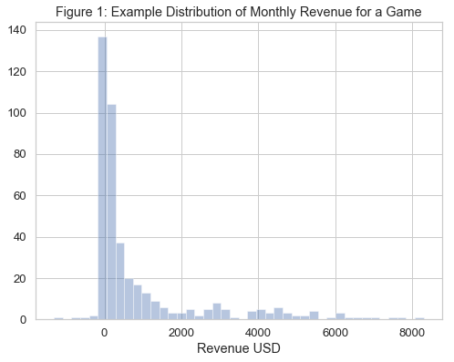

```python
plt.figure(figsize=ncol1)
sns.distplot(df_raw[df_raw['Game ID'] == 4]['Revenue USD'], kde=False)
plt.title(fig_counter() + 'Example Distribution of Monthly Revenue for a Game');
```

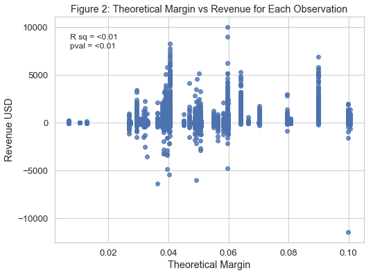

```python
regplot_annot('Theoretical Margin', 'Revenue USD', data=df_raw, fit_reg=False)
plt.title(fig_counter() + 'Theoretical Margin vs Revenue for Each Observation');
```

### 1.1 Variables Used for Analysis

To better evaluate game performance, the mean `Wagers USD`, `Wins USD` and `Revenue USD` per month across all operators for each game is used. This should also dilute the influence of games launched part way in to a month which will have artificially low values for that month.

```python
# add number of observations for each game
df_raw['n Observations'] = df_raw.groupby('Game ID')['Game ID'].transform('count')
```

```python
# sum for each game over all operators
df_game = df_raw.groupby(['Game ID', 'Theoretical Margin', 'n Observations']).sum().reset_index()
```

```python
# mean per month for each game over all operators
df_game['Spins per Month'] = df_game['Number of Spins'] / df_game['n Observations']
df_game['Wagers per Month USD'] = df_game['Wagers USD'] / df_game['n Observations']
df_game['Revenue per Month USD'] = df_game['Revenue USD'] / df_game['n Observations']
df_game['Actual Margin'] = df_game['Revenue USD'] / df_game['Wagers USD']
```

This gives the following main variables used for further analysis and creation of other features:

```python
print(table_counter() + 'Variables used for Analysis')
df_game.head()
```

```
Table 2: Variables used for Analysis
```

|  | Game ID | Theoretical Margin | n Observations | Number of Spins | Wagers USD | Wins USD | Revenue USD | Actual Margin | Spins per Month | Wagers per Month USD | Revenue per Month USD |
| --- | --- | --- | --- | --- | --- | --- | --- | --- | --- | --- | --- |
| 0 | 1 | 0.03225 | 261 | 157837 | 236068.49 | 229094.25 | 6974.24 | 0.029543 | 604.739464 | 904.476973 | 26.721226 |
| 1 | 2 | 0.05966 | 330 | 183034 | 198578.35 | 190795.72 | 7782.63 | 0.039192 | 554.648485 | 601.752576 | 23.583727 |
| 2 | 3 | 0.10049 | 254 | 192028 | 272359.28 | 243737.47 | 28621.81 | 0.105088 | 756.015748 | 1072.280630 | 112.684291 |
| 3 | 4 | 0.04040 | 420 | 6495532 | 8906694.03 | 8531121.08 | 375572.95 | 0.042167 | 15465.552381 | 21206.414357 | 894.221310 |
| 4 | 5 | 0.02683 | 190 | 54194 | 151898.71 | 154207.26 | -2308.55 | -0.015198 | 285.231579 | 799.466895 | -12.150263 |

## 2. Correlation of Main Variables

Figure 3 shows the correlations between the main independent variables `Theoretical Margin` and `Wagers per Month USD` against the main dependant variables `Actual Margin` and `Revenue per Month USD` for each game over all operators. The shaded area shows where the regression line may lie for a 95% confidence level. The R squared correlation indicator and p-value statistical significance are also shown.

**Effect of Theoretical Margin on Revenue**

There is no correlation between `Theoretical Margin` and `Revenue per Month USD`. The margin a game is designed for cannot alone predict how much revenue the game will generate. It can be used to estimate revenue if the amount wagered is known. See Section 4 for further discussion.

**Revenue from Wagers**

**Effect of Theoretical Margin on Actual Margin**

There appears to be no correlation between `Theoretical Margin` and `Actual Margin` (p-value > 0.05). However, this is due to outliers with high leverage, i.e. they lie far from the regression line and distort the linear model. These outliers are 3 games which have low `Theoretical Margin`s but higher `Actual Margin`s. Figure 9 in Section 4.1 shows the same chart with cleaned data and a statistically significant relationship with some correlation (R squared = 0.64). See Section 4 for further discussion.

**Effect of Game Popularity on Actual Margin**

Games which are played less have higher variation in `Actual Margin`s and therefore higher variations in revenue (as shown by `Wagers per Month USD` vs `Actual Margin`). This is due to the inherent volatility of gambling and follows the law of large numbers: the more a game is played, the more the `Actual Margin` will tend towards the true `Theoretcial Margin`. See Section 3 for further discussion.

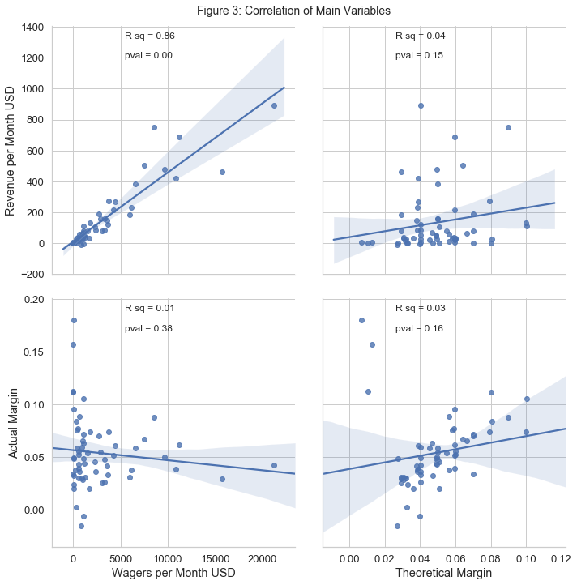

```python
plotr = df_game[['Wagers per Month USD', 'Revenue per Month USD', 'Theoretical Margin', 'Actual Margin']]

g = sns.PairGrid(plotr, x_vars={'Wagers per Month USD', 'Theoretical Margin'},
                        y_vars={'Revenue per Month USD', 'Actual Margin'}, height=5)
g.map(sns.regplot)
g.map(corrfunc)
g.fig.suptitle(fig_counter() + 'Correlation of Main Variables', y=1.005, fontsize=title_size);
```

**Effect of Theoretical Margin on Game Popularity**

Figure 4 shows there is no relationship between `Theoretical Margin` and how much the game is played (`Spins per Month`). Lower margin games which pay out more to the player won't necessarily mean they'll be played more often. See Section 5 for further discussion.

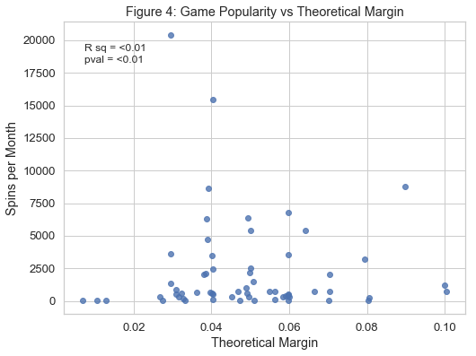

```python
regplot_annot('Theoretical Margin', 'Spins per Month', data=df_game, fit_reg=False)
plt.title(fig_counter() + 'Game Popularity vs Theoretical Margin');
```

**Mean Wager per Spin per Game**

As expected, `Spins per Month`, `Wagers per Month USD` and `Revenue per Month USD` are all highly correlated with each other (see Figure 16 in Appendix A1). This means that `Spins per Month` and `Wagers per Month USD` are colinear with respect to `Revenue per Month USD` and are used fairly interchangeably in this analysis. The mean wager per spin is 1.4 USD.

Figure 5.1 and 5.2 demonstrates this close relationship. Each game has an 'o' with a corresponding 'x' both plotted at that game's `Revenue per Month USD` value and coloured for ease of identification, i.e. the 'o' and 'x' for each game are horizontally separated.

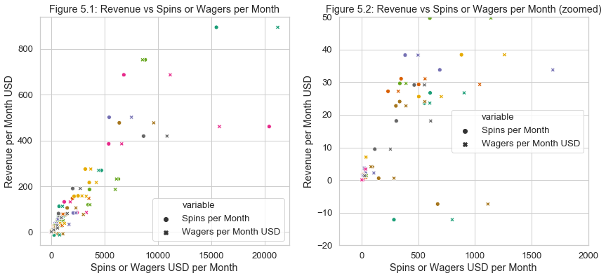

```python
df_game_melted = df_game[['Game ID', 'Spins per Month', 'Wagers per Month USD', 'Revenue per Month USD']].\
    melt(['Revenue per Month USD', 'Game ID'])

fig, axes = plt.subplots(ncols=2, figsize=ncol2)

for xn in (0,1):
    axes[xn] = sns.scatterplot('value', 'Revenue per Month USD', data=df_game_melted, ax=axes[xn],
                               style='variable', hue='Game ID', palette='Dark2')
    axes[1].set_xlim(-200,2e3)
    axes[1].set_ylim(-20,50)
    handles, labels = axes[xn].get_legend_handles_labels()
    axes[xn].legend(handles=handles[6:])
    axes[xn].set(title=fig_counter(xn) + 'Revenue vs Spins or Wagers per Month' + ' (zoomed)' * xn,
                 xlabel='Spins or Wagers USD per Month')
```

```python
# mean wager per spin USD
round((df_game['Wagers USD'] / df_game['Number of Spins']).mean(), 2)
```

```
1.43
```

## 3. Game Stability and Data Cleaning

In order to better achieve the objectives of this study, unstable games with high variation in their `Actual Margin` and resulting `Revenue per Month USD` should be removed. Games that are not played as much, i.e. low `Spins per Month` and therefore low `Wagers per Month USD`, tend to be more unstable and display more noise in their dependent variables `Revenue per Month USD` and `Actual Margin` (illustrated by Figure 3). Removing these games helps draw better conclusions.

Game stability is measured by calculating the ratio of theoretical revenue a game should generate per month to how much it actually generates:

`Theoretical Revenue per Month USD` = `Wagers per Month USD` x `Theoretical Margin`

`Revenue Ratio` = `Revenue per Month USD` / `Theoretical Revenue per Month USD`

Games with `Revenue Ratio` close to 1 generate the theoretical revenue and are considered stable. `Revenue Ratio`s above 1 indicate a game has generated more revenue than it was designed for.

```python
# add measure of game stability
df_game['Theoretical Revenue per Month USD'] = df_game['Wagers per Month USD'] * df_game['Theoretical Margin']
df_game['Revenue Ratio'] = df_game['Revenue per Month USD'] / df_game['Theoretical Revenue per Month USD']
```

Due to the inherent volatility of gambling games, those games with few observations may provide erroneous data in accordance with the law of large numbers. However, the number of observations (i.e. game data per operator per month) does not have an effect on game stability (see Figure 17.1 and 17.2 in Appendix A2) and no games are removed due to lack of observations.

Figure 6.1 and 6.2 show that less popular games have more variation in stability (`Revenue Ratio`) and is analagous to the `Actual Margin` vs `Wagers per Month USD` panel in Figure 3 though `Number of Spins` is used here as a slightly better metric for game popularity.

Games below 350 `Spins per Month` will be removed from the remainder of the analysis. Figure 6.2 zooms in on the region with highest variation, excluding the 3 games with very high `Revenue Ratio` which all have below 40 spins per month (Table 3). The shaded area shows the games to be removed.

```python
# number of spins per month for the 3 outliers
print(table_counter() + 'High Revenue Ratio Games')
df_game[df_game['Revenue Ratio'] > 5][['Revenue Ratio', 'Spins per Month']].round(1)
```

```
Table 3: High Revenue Ratio Games
```

|  | Revenue Ratio | Spins per Month |
| --- | --- | --- |
| 12 | 10.7 | 9.2 |
| 15 | 12.3 | 21.4 |
| 38 | 26.5 | 38.3 |

```python
n_spins_cutoff = 350
```

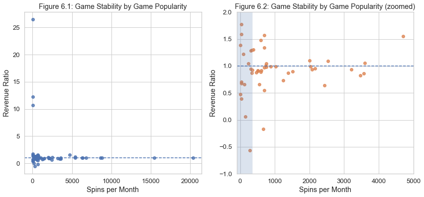

```python
fig, axes = plt.subplots(ncols=2, figsize=ncol2)

for xn in (0,1):
    axes[xn] = sns.regplot(df_game['Spins per Month'], df_game['Revenue Ratio'], ax=axes[xn], fit_reg=False)
    axes[xn].axhline(1, linestyle='--')
    axes[1].axvspan(-100, n_spins_cutoff, alpha = 0.1)
    axes[1].set_xlim(-100,5000)
    axes[1].set_ylim(-1,2)
    axes[xn].set(title=fig_counter(xn) + 'Game Stability by Game Popularity' + ' (zoomed)' * xn,
                 xlabel='Spins per Month')
```

With reference to Figure 6.2, it could be tempting to remove all games with less than 1000 `Spins per Month` as this seems to be where variation in `Revenue Ratio` reduces significantly. However, this would remove too many games, around 60%. A trade-off must be made between removing unstable games and an leaving an acceptable amount of games for further analysis.

To assist in determining the `Spins per Month` cut-off point as 350, the rolling `Revenue Ratio` standard deviation is calculated and shown in Figure 7.1 and 7.2. 3 rolling standard deviations are plotted, using 5, 7 and 9 games in their respective calculations (8-15% of all games). These are referred to as a 'window'. Various window sizes are used to provide a good overall picture of the trend. As this is not a rigorous method of selection, only intended as a useful guideline, the 3 outliers with large `Revenue Ratio`s above 10 are excluded from this calculation as they will erroneously distort results.

Figure 7.2 shows that there is a sharp drop in variation (`Revenue Ratio SD`) at around 350 `Spins per Month` which also happens to coincide with the mean standard deviation of about 0.4. The standard deviation does increase after this point due to the levarge of a few games around 700 `Spins per Month`.

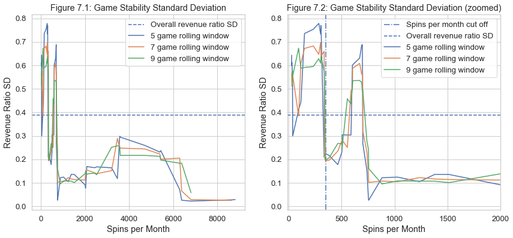

```python
Revenue_Ratio_std = df_game[df_game['Revenue Ratio'] < 5]['Revenue Ratio'].std()

fig, axes = plt.subplots(ncols=2, figsize=ncol2)
axes[1].axvline(n_spins_cutoff, linestyle='-.', label='Spins per month cut off ')
fig_num = fig_num - 2

for xn in (0,1):
    axes[xn].axhline(Revenue_Ratio_std, linestyle='--', label='Overall revenue ratio SD')

for window in (5,7,9):
    n_spins_roll = df_game.loc[df_game['Revenue Ratio'] < 5,['Spins per Month', 'Revenue Ratio']].\
                   sort_values('Spins per Month').\
                   rolling(window, on='Spins per Month', center=True).std().\
                   rename(columns={'Revenue Ratio': 'Revenue Ratio SD'})

    for xn in (0,1):
        sns.lineplot('Spins per Month', 'Revenue Ratio SD', data=n_spins_roll, ax=axes[xn],
                     label=str(window) + ' game rolling window')
        axes[1].set_xlim(-10, 2000)
        axes[xn].set_title(fig_counter(xn) + 'Game Stability Standard Deviation' + ' (zoomed)' * xn)
```

```python
for cutoff in (n_spins_cutoff, 1000):
    print('For cut off at ' + str(cutoff) + ' spins per month, fraction games removed = ' +
          str(round(sum(df_game['Spins per Month'] < cutoff) / len(df_game), 2)))
```

```
For cut off at 350 spins per month, fraction games removed = 0.33
For cut off at 1000 spins per month, fraction games removed = 0.61
```

*The cleaned data frame with values for each game per month is created here.*

```python
# remove games with low spins per month
df = df_game[df_game['Spins per Month'] > n_spins_cutoff].copy()
```

```python
print('From', str(len(df_game)), 'games in raw data,', str(len(df)), 'remain')
```

```
From 61 games in raw data, 41 remain
```

### 3.1 Are Games Underperforming?

It seems that there are more games below the `Revenue Ratio` = 1 line in Figure 6.1 and 6.2 than there are above. This would suggest that more games generate less revenue than they should. If a threshold of +/- 5% `Revenue Ratio` is applied to categorise a game as over performing or under performing, then about 40% of games under perform and about 20% over perform.

```python
frac_better = len(df[df['Revenue Ratio'] > 1.05]) / len(df)
frac_worse = len(df[df['Revenue Ratio'] < 0.95]) / len(df)
print(str(round(frac_better * 100)) + '% of games perform better than expected')
print(str(round((1 - frac_better - frac_worse) * 100)) + '% of games perform about as expected')
print(str(round(frac_worse * 100)) + '% of games perform worse than expected')
print('The mean Revenue Ratio is', round(df['Revenue Ratio'].mean(), 2))
```

```
22% of games perform better than expected
39% of games perform about as expected
39% of games perform worse than expected
The mean Revenue Ratio is 0.97
```

To see if the games in this analysis are under performing or its just a consequence of a small sample size of 41 games, the following hypothesis test is performed at a significance level of 5%:

Null hypothesis: mean population `Revenue Ratio` = 1

Alternative hypothesis: mean sample `Revenue Ratio` is actually less than that of the population

$H_{0}$: $\mu_{Revenue Ratio}$ = 1

$H_{a}$: $\mu_{Revenue Ratio}$ < 1

In other words, given that all online slot games will have a mean `Revenue Ratio` of 1, is there evidence in these data to suggest that the games used in this analysis are actually underperforming?

In order to perform the hypothesis test, the following conditions must be met:

**Independence:** Each game can be assumed to be independent of each other. One game's performance has no effect on another.

**Normality:** Given the low sample size of 41, normally distributed values are required. This is the case as shown in Figure 8.

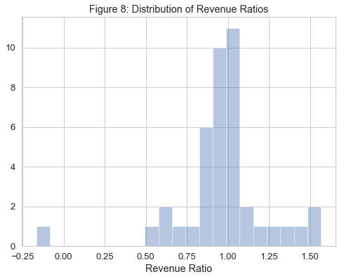

```python
plt.figure(figsize=ncol1)
sns.distplot(df['Revenue Ratio'], kde=False)
plt.title(fig_counter() + 'Distribution of Revenue Ratios');
```

A one-sided t-test is perfomed against the population mean of 1 and results in a p-value of 0.26. This is well above the significance level of 5% (or 0.05) so we fail to reject the null hypothesis that the mean `Revenue Ratio` of games in this analysis are the same as all online slot games.

Figure 8 above highlights one outlier game with a negative `Revenue Ratio` meaning this game has on average cost operators money instead of generating revenue. This outlier has some levarage in distorting the overall mean but should still be taken in to account.

In summary, the games in this analysis just happen to perform slightly worse on average than they should. This is in part due to the outlier with a negative `Revenue Ratio`. If more games were included in the analysis then it is likely that a similar amount of games will over perform as will under perform.

```python
from scipy import stats
```

```python
# t test p-value
t_test = stats.ttest_1samp(df['Revenue Ratio'], 1)
(t_test.pvalue / 2).round(2)
```

```
0.26
```

## 4. Revenue Estimation

### 4.1 Regression of Revenue vs Wagers

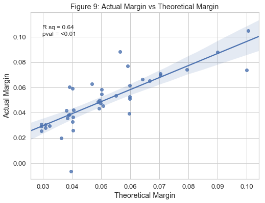

```python
regplot_annot('Theoretical Margin', 'Actual Margin', data=df, ci=95)
plt.title(fig_counter() + 'Actual Margin vs Theoretical Margin');
```

In order to better understand the relationship between `Theoretical Margin` and `Actual Margin`, games are grouped in to 3 bins of similar `Theoretical Margin`s with approximatley the same number of games per bin to aid statistical analysis. The binning of games methodology is further discussed in Appendix A3.

```python
# bin theoretcial margins
# note: precision has to be set to 4 otherwise ungainly bin labels are produced
df['Theoretical Margin Bin'] = pd.qcut(df['Theoretical Margin'], 3, precision = 4)
```

```python
# number of games per bin
df.groupby('Theoretical Margin Bin').count()['Game ID']
```

```
Theoretical Margin Bin
(0.0293, 0.04012]     15
(0.04012, 0.05592]    12
(0.05592, 0.1005]     14
Name: Game ID, dtype: int64
```

Figure 10 shows `Revenue per Month USD` vs `Wagers per Month USD` with a regression line for each `Theoretical Margin Bin`. Since `Actual Margin` is calculated from `Revenue USD` / `Wagers USD`, the gradient of these lines will reveal a better way to estimate the `Actual Margin` of each bin.

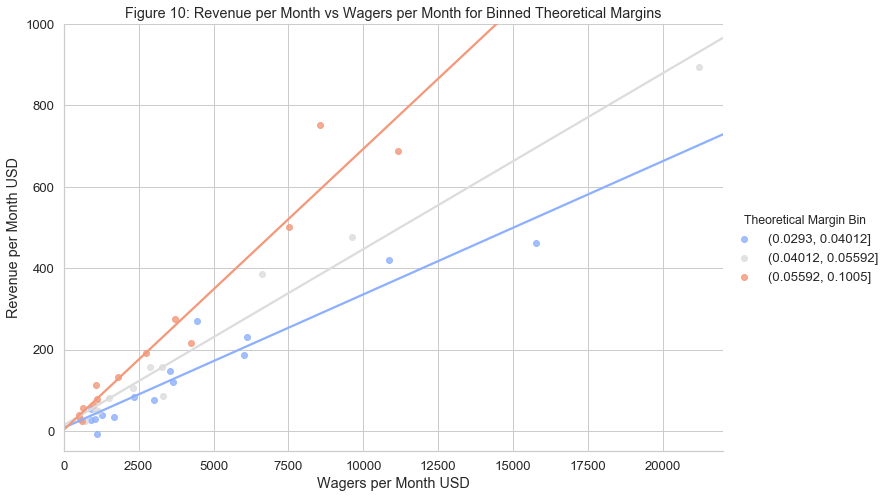

```python
sns.lmplot('Wagers per Month USD', 'Revenue per Month USD', data=df, hue='Theoretical Margin Bin', ci=False,
           palette='coolwarm', height=7, aspect=1.5)
axes = plt.gca()
axes.set_ylim(-50,1e3)
axes.set_xlim(0,2.2e4)
axes.set_title(fig_counter() + 'Revenue per Month vs Wagers per Month for Binned Theoretical Margins');
```

```python
# run regression for each bin (ols = ordinary least squares, the linear regression method)
def run_ols(df, qbin, wagers_per_month_USD=0):
    y = df.loc[df['Theoretical Margin Bin']==qbin, 'Revenue per Month USD']
    X = df.loc[df['Theoretical Margin Bin']==qbin, 'Wagers per Month USD']
    model = sm.OLS(y, X).fit()
    pred = model.predict(wagers_per_month_USD)
    return qbin, round(model.params[0], 3), model.bse[0], round(model.rsquared, 2),\
        round(model.pvalues[0], 4), model.resid, X, y, pred
```

```python
# create data frame with regression results, including nested data
def get_reg_res(df):
    res_df = pd.DataFrame([run_ols(df, mbin, df.loc[df['Theoretical Margin Bin'] == mbin, 'Wagers per Month USD'])
                               for mbin in df['Theoretical Margin Bin'].unique()],
                           columns=('Theoretical Margin Bin', 'Gradient', 'SE', 'r squared', 'p-value',
                                 'Residual USD', 'Wagers per Month USD', 'Revenue per Month USD', 'Prediction USD'))

    res_df['Min Gradient'] = round(res_df['Gradient'] - 1.96 * res_df['SE'], 3)
    res_df['Max Gradient'] = round(res_df['Gradient'] + 1.96 * res_df['SE'], 3)
    res_df['p-value'] = res_df['p-value'].apply(lambda x: '< 0.01' if x < 0.01 else x)
    res_df['Actual Margin'] = res_df['Revenue per Month USD'] / res_df['Wagers per Month USD']

    margin_bin_mean = round(df.groupby('Theoretical Margin Bin').mean()\
                        [['Theoretical Margin', 'Actual Margin']], 3).reset_index()
    margin_bin_mean.rename(columns={'Theoretical Margin':'Mean Theoretical Margin',
                                    'Actual Margin':'Mean Actual Margin'}, inplace=True)
    return res_df.merge(margin_bin_mean, on='Theoretical Margin Bin').sort_values('Theoretical Margin Bin')
```

```python
reg_res = get_reg_res(df)
```

Table 4 summarises the linear regression output. Since the y-intercept standard error at a 95% confidence level for each regression includes zero and obtaining a value for revenue for zero wagers is not possible, regression has been performed with no y-intercept i.e. each line will pass through zero on the y-axis.

Each regression is statistically significant at a significance level of 5% with p-values below 0.01. R squared values of 0.95 and over for each regression show good correlations for each bin.

The `Mean Theoretical Margin` and `Mean Actual Margin` for each bin are approximately equal to each other and to the corresponding regression `Gradient`. The mean margins are also within the 95% confidence interval for their `Gradient` as shown by `Min Gradient` and `Max Gradient`. This coupled with the statistical significance and good correlations shows that indeed the `Gradient` approximates well to `Actual Margin` and therefore `Theoretical Margin` is a good indicator for revenue.

Revnue estimates can be made using:

`Theoretical Revenue per Month USD` = `Wagers per Month USD` x `Theoretical Margin`

*Note that the y-intercept has been set to zero so there is no constant term in these regressions*

It can be seen that the `Gradient` for each regression is slightly lower than the respective `Mean Theoretical Margin` and could signify that on average `Actual Margin`s are lower than `Theoretical Margin`s and games will under perform. However, this is due to the games in this analysis slightly under performing overall and is discussed in Section 3.1. If more games were used in this analysis, it is likely that `Gradient` would align even more closely with `Mean Theoretical Margin`.

`Max Gradient` for the `(0.04012,0.05592]` bin is equal to the `Mean Actual Margin` implying the `Gradient` for this bin is only equal at the upper limit of it's 95% confidence interval. This is due to this bin mainly incorporating `Theoretical Margin`s around 0.05 but also some close to 0.04. See Appendix A3 for further details.

```python
print(table_counter(), 'Regression Summary')
reg_res[['Theoretical Margin Bin', 'p-value', 'r squared', 'Mean Theoretical Margin', 'Mean Actual Margin',
         'Gradient', 'Min Gradient', 'Max Gradient']]
```

```
Table 4:  Regression Summary
```

|  | Theoretical Margin Bin | p-value | r squared | Mean Theoretical Margin | Mean Actual Margin | Gradient | Min Gradient | Max Gradient |
| --- | --- | --- | --- | --- | --- | --- | --- | --- |
| 0 | (0.0293, 0.04012] | < 0.01 | 0.95 | 0.035 | 0.033 | 0.034 | 0.030 | 0.038 |
| 2 | (0.04012, 0.05592] | < 0.01 | 0.99 | 0.048 | 0.047 | 0.044 | 0.041 | 0.047 |
| 1 | (0.05592, 0.1005] | < 0.01 | 0.97 | 0.071 | 0.070 | 0.069 | 0.063 | 0.075 |

### 4.2 Regression Diagnostics

Diagnostics on rediuals from the 3 regressions were performed. Residuals are differences between the actual value and the regression model's prediction calculated as:

`Residual USD` = `Revenue per Month USD` - `Prediction USD`

**Linearity:** There is a strong linear correlation between `Wagers per Month USD` and `Revenue per Month USD`.

**Independence:** Each game can be assumed to be independent of each other. One game's performance has no effect on another.

**Normality:** Residual distributions in Figure 11.1, 11.2 and 11.3 show good approximation to normality given the small sample sizes.

```python
# unnest Wagers per Month USD and Residuals
reg_wpm = pd.DataFrame(reg_res['Wagers per Month USD'].tolist()).melt(value_name='Wagers per Month USD')
reg_resid = pd.DataFrame(reg_res['Residual USD'].tolist()).melt(value_name='Residual USD')
reg_res_unnest = pd.merge(pd.merge(reg_wpm, reg_resid, left_index=True, right_index=True).dropna(),
                          df[['Wagers per Month USD', 'Theoretical Margin Bin']])
```

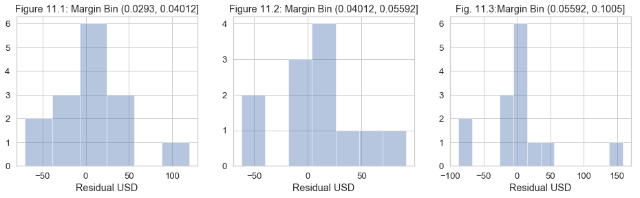

```python
mbin = df['Theoretical Margin Bin'].unique().sort_values()
fig, axes = plt.subplots(ncols=3, figsize=(16,4))

for xn in (0,1,2):
    axes[xn] = sns.distplot(reg_res_unnest.loc[reg_res_unnest['Theoretical Margin Bin'] == mbin[xn], 'Residual USD'],
                            kde=False, ax=axes[xn])
    if xn != 2:
        axes[xn].set(title=fig_counter(xn) + 'Margin Bin ' + str(mbin[xn]), xlabel='Residual USD')
    else:
        axes[xn].set(title='Fig. ' + str(fig_num) + '.3:' + 'Margin Bin ' + str(mbin[xn]), xlabel='Residual USD')
```

**Outliers:** By inspection of Figure 10 and due to regression `Gradient`s closely matching the `Mean Theoretical Margin`s, the leverage of any outliers appears to be minimal. For example, the highly unstable game with a negative `Revenue Ratio` identified in Section 3.1 has little leverage on fitting the regression line but distorts prediction errors calculated in Section 4.3.

**Constant Variance (Homoscedasticity) of Residuals:** Figure 12 shows the regression model residuals for each bin and the lack of constant variance. After approximately 4500 `Wagers per Month USD` variance increases greatly.

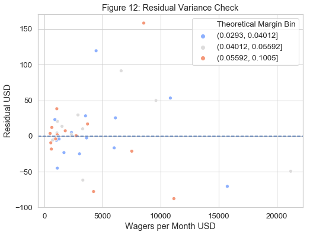

```python
plt.figure(figsize=(ncol1))
sns.scatterplot('Wagers per Month USD', 'Residual USD', hue='Theoretical Margin Bin',
                data=reg_res_unnest, palette='coolwarm')
plt.axhline(0, ls='--')
plt.title(fig_counter() + 'Residual Variance Check');
```

### 4.3 Prediction Errors

A more useful interpretation of Figure 12 above is to calculate how far off the estimated `Theoretical Revenue per Month USD` is from the actual `Revenue per Month USD`. A `Residual USD` of 10 for 1000 `Wagers per Month USD` is a larger error than a 20 `Residual USD` for 10,000 `Wagers per Month USD`.

Since it has been shown that the `Gradient` equates to `Theoretical Margin` which can be used as a good estimator for `Actual Margin` and therefore `Revenue per Month USD`, Figure 13 plots the `% Prediction Error` as how far off the `Theoretical Revenue per Month USD` is from the actual `Revenue per Month USD` for each game (excluding the negative revenue outlier with -700% error).

`% Prediction Error` = (`Theoretical Revenue per Month USD` x 100 / `Revenue per Month USD`) - 100

A positive `% Prediction Error` indicates the regression over predicted the actual value. Note that this prediction error is an alternative way of presenting `Revenue Ratio`. With reference to Section 3.1, the same observation of more games predicted to generate more revenue than they actually do can be seen. This is likely due to few games being used in the analysis.

In accordance with less popular games being more unstable, predictions will be further off for less popular games with lower `Wagers per Month USD`. At around 5000 `Wagers per Month USD`, the `% Prediction Error` reduces significantly. This could be a useful guide for approximately how much `Wagers per Month USD` you would need to achieve for your game to generate it's expected revenue.

```python
# obtain prediction errors
df['% Prediction Error'] = (df['Theoretical Revenue per Month USD'] * 100 / df['Revenue per Month USD']) - 100
```

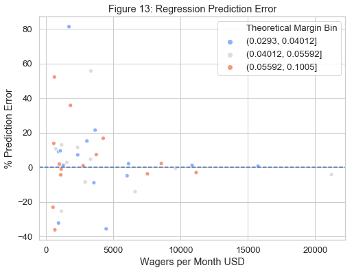

```python
plt.figure(figsize=ncol1)
sns.scatterplot('Wagers per Month USD', '% Prediction Error', hue='Theoretical Margin Bin', palette='coolwarm',
               data=df[df['% Prediction Error'] > -50])
plt.axhline(0, ls='--')
plt.title(fig_counter() + 'Regression Prediction Error')
plt.grid(b=True, which='minor', color='w', linewidth=0.5);
```

### 4.4 Regression Conclusion

All regression diagnostic tests were satisfied except constant variance of the residuals which is to be expected. These regression models are valid so long as this caveat is taken in to account. Regression has shown that `Theoretical Margin` can be applied directly to the amount wagered on the game over any time period to estimate revenue:

*Estimated Revenue = Predicted Revenue $\pm$ Error*

*Predicted Revenue = Wagers x `Theoretical Margin`*

*Error = Predicted Revenue x `Mean Absolute % Error`*

Where the `Mean Absolute % Error` is obtained from Table 5 according to how much `Wagers per Month USD` the game receives.

Games with less than 350 `Spins per Month` that have been excluded thus far can now be included in error calculations. The equivalent `Wagers per Month USD` cut-off is 350 x 1.4 USD per spin = 500 USD. Table 5 also shows how many games are used to estimate this error. Three games with very large `% Prediction Error`s have been removed as these greatly distort the error calculation. No estimtes for differences in `Mean Absolute % Error` for different `Theoretical Margin`s can be made as these sub groups contain too few games to produce reliable results.

For example:

1000 `Wagers per Month USD` x 0.05 `Theoretical Margin` = 50 USD

Error = 50 USD x 17% `Mean Absolute % Error` = $\pm$ 9 USD

Estimated average revenue per month is 50 USD and can be expected to be between 41 USD and 59 USD on average.

10,000 `Wagers per Month USD` x 0.01 `Theoretical Margin` = 100 USD

Error = 100 USD x 4% `Mean Absolute % Error` = $\pm$ 4 USD

Estimated average revenue per month is 100 USD and can be expected to be between 96 USD and 104 USD on average.

```python
# calculate mean percentage errors for whole data set
df_game['% Prediction Error'] =\
    (df_game['Theoretical Revenue per Month USD'] * 100 / df_game['Revenue per Month USD']) - 100
df_error = df_game[(df_game['% Prediction Error'] > -200) & (df_game['% Prediction Error'] < 500)].copy()
df_error['Wagers per Month USD Bin'] = pd.cut(df_error['Wagers per Month USD'], (0, 500, 5000, 25000))
df_error['Abs % Prediction Error'] = abs(df_error['% Prediction Error'])
print(table_counter() + 'Mean Absolute Percentage Error for Predictions')
df_error.groupby('Wagers per Month USD Bin').agg(['mean', 'count'])['Abs % Prediction Error'].round(1)
```

```
Table 5: Mean Absolute Percentage Error for Predictions
```

| Wagers per Month USD Bin | mean | count |
| --- | --- | --- |
| (0, 500] | 55.2 | 16 |
| (500, 5000] | 17.3 | 32 |
| (5000, 25000] | 3.7 | 10 |

## 5. Game Popularity

Now that it has been determined that we can obtain good estimates of revenue from `Theoretical Margin` given the game is played enough, is it possible to estimate how much a game will be played from `Theoretical Margin` and how stable it will be using cleaned data? This would give a better idea of how much revenue the game could make depending on what `Theoretical Margin` it is designed for.

Figure 14 shows `Spins per Month` vs `Theoretcial Margin`. As with the raw data in Figure 4, Section 2 there does not appear to be a relationship between the two.

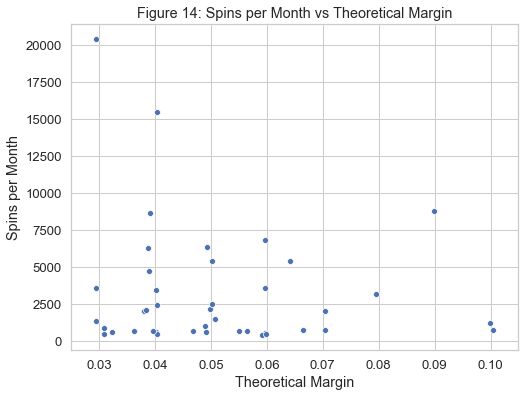

```python
plt.figure(figsize=ncol1)
sns.scatterplot('Theoretical Margin', 'Spins per Month', data=df)
plt.title(fig_counter() + 'Spins per Month vs Theoretical Margin');
```

Figure 15 shows the distribution of `Spins per Month` per `Theoretical Margin Bin` (2 games with approximatley 15,000 and 20,000 `Spins per Month` are not shown). The distribution of low margin games is higher and the median for higher margin games is lower, suggesting that higher margin games are played less. This makes sense as these games pay out less to the player, but is there a statistical difference between the 3 groups?

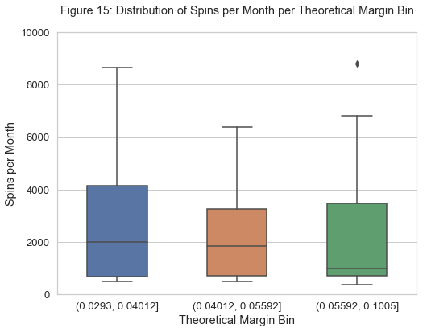

```python
plt.figure(figsize=ncol1)
sns.boxplot('Theoretical Margin Bin', 'Spins per Month', data=df, width=0.5)
plt.ylim(0, 1e4)
plt.title(fig_counter() + 'Distribution of Spins per Month per Theoretical Margin Bin', y=1.05);
```

An analysis of variance (ANOVA) test shows that there is no statistical difference between the mean `Spins per Month` of each group, i.e. we cannot tell from these data that `Theoretical Margin` has an effect on how much the game is played and therefore how much revenue it will generate.

The ANOVA test gave this result as the F-statistic p-value of 0.73 is well above a 5% significance level. The ANOVA assumptions of normality and homogenous variance are valid due to similar sized groups and the independence of observations/games.

```python
# ANOVA F-statistic p-value
df_dummy = pd.get_dummies(df['Theoretical Margin Bin'], drop_first=True)
sm.OLS(df['Spins per Month'], sm.add_constant(df_dummy)).fit().f_pvalue.round(2)
```

```
0.73
```

Since the measure of game stability `Revenue Ratio` is a function of `Wagers per Month` and therefore `Spins per Month`, this too cannot be determined by `Theoretical Margin`. This has been checked in Appendix Section A4.

## 6. Conclusion and Recommendations

`Theoretical Margin` does not have an effect on game success. It alone will not determine how much the game is played and how much total revenue will be generated. However, it can be used to estimate revenue within an average error margin if there are estimates of how much the game will be played.

Games will only produce reliable revenues that match their `Theoretical Margin` once they are played enough. According to these data, an estimated 5000 `Wagers per Month USD` on average is needed. With reference to Figure 6.1 in Section 3, this can be translated to a more generic 5000 `Spins per Month`. `Theoretical Margin` does not effect how stable a game will be.

In order to provide better estimates for revenue given how much a game is played, more games need to be included in the analysis. This would enable regression to be performed on groups of games with better matching `Theoretical Margins` (e.g. a bin for 0.05 containing 0.045 to 0.055, 0.06 $\pm$0.005 and so on), which would enable more accurate estimates for errors and provide confidence intervals for estimated revenue.

Game success is more likely dependent on other factors such as the game's maths, how much is spent marketing it and it's position on the website/visibility. Given that game sucess is independent of `Theoretical Margin` and there is a strong correlation between `Theoretical Margin` and `Actual Margin`, games with higher `Theoretical Margin`s will generate more revenue in the long run.

Further analysis could include analysing game performance over time and how the positioning of a game on a website effects performance.

## Appendix

### A1. Cleaned Data Correlations

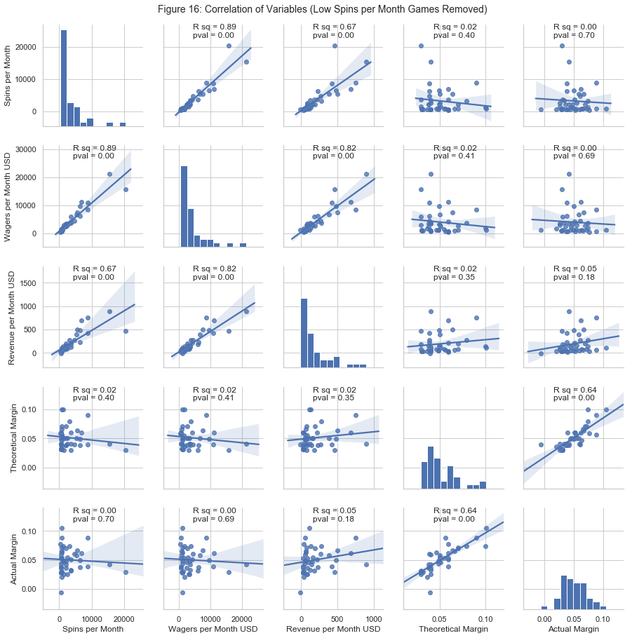

```python
sns.set(style='whitegrid', font_scale=1)
plotr = df[['Spins per Month', 'Wagers per Month USD', 'Revenue per Month USD',
            'Theoretical Margin', 'Actual Margin']]
g = sns.PairGrid(plotr)

g.map_diag(plt.hist)
g.map_upper(sns.regplot)
g.map_upper(corrfunc)
g.map_lower(sns.regplot)
g.map_lower(corrfunc)
g.fig.suptitle(fig_counter() + 'Correlation of Variables (Low Spins per Month Games Removed)', y=1.01, fontsize=14);
```

### A2. Number of Observations per Game

Due to the inherent volatility of gambling games, those games with few observations may provide erroneous data in accordance with the law of large numbers. Figure 17.1 and 17.2 plots game stability (`Revenue Ratio`) against number of observations per game.

There are 3 games that generate many times more revenue than they should, though these outliers aren't determined by number of observations. Figure 17.2 excludes these outliers and shows that game stability does not appear to be affected by number of observations.

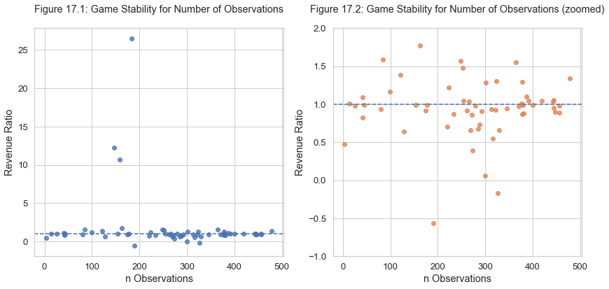

```python
sns.set(style='whitegrid', font_scale=1.2)
fig, axes = plt.subplots(ncols=2, figsize=ncol2)

for xn in (0,1):
    axes[xn] = sns.regplot('n Observations', 'Revenue Ratio', data=df_game, ax=axes[xn], fit_reg=False)
    axes[xn].axhline(1, linestyle='--')
    axes[1].set_ylim(-1,2)
    axes[xn].set_title(fig_counter(xn) + 'Game Stability for Number of Observations' + ' (zoomed)' * xn, y=title_y)
```

### A3. Theoretical Margin Bins

The `Theoretical Margin` grouping method used in the main report creates bins with similar sizes which facilitates comparison of regression lines, game popularity and stability between groups and enables sound statistical inferences to be made. The disadvantage of this method is slight skewing of the `Gradient` for the middle bin as mentioned in Section 4.1. Some games included in the middle bin `(0.04012, 0.05592]` would logically belong in the lower bin as illustrated by Figure 18. However, doing so would create unequally sized bins with few observations in the middle bin (Table 6).

Ultimately, regression was used to show that a game's `Theoretical Margin` could be applied directly to it's wagers to estimate revenue with an associated mean error. The regression coefficent (`Gradient`) is not applied to the independent variable (`Wagers per Month USD`) to find the dependent variable (`Revenue per Month USD`). Therefore the slight skew is not an issue and the equally sized bins were retained for game popularity and stability ANOVA tests.

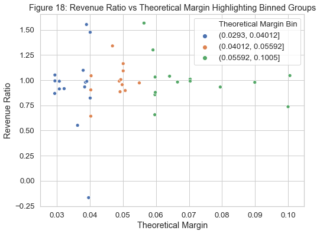

```python
plt.figure(figsize=ncol1)
sns.scatterplot('Theoretical Margin', 'Revenue Ratio', data=df, hue='Theoretical Margin Bin')
plt.title(fig_counter() + 'Revenue Ratio vs Theoretical Margin Highlighting Binned Groups');
```

```python
# manually create theoretical margin bins
df['Modified Theoretical Margin Bin'] = pd.cut(df['Theoretical Margin'], [0.029, 0.045, 0.056, 0.11])
```

```python
print(table_counter() + 'Games per Bin')
df.groupby('Modified Theoretical Margin Bin').count()['Game ID']
```

```
Table 6: Games per Bin
```

```
Modified Theoretical Margin Bin
(0.029, 0.045]    18
(0.045, 0.056]     9
(0.056, 0.11]     14
Name: Game ID, dtype: int64
```

To try and equalise group size and create more logical groups, bins centered around `Theoretical Margin`s rounded to 2 decimal places is considered for regression (games between 0.07 and 0.1 have their own group). This had the effect of producing even better correlations, R squared increased from an already good 0.95 to 0.99 and reducing standard error of the coefficients (gradients). However, residuals were not normally distributed, likely a result of small group sizes, so this method was not employed.

```python
# manually create rounded theoretical margin bins
df['Round Margin Bin'] = round(df['Theoretical Margin'],2).apply(lambda x: str(x) if x <= 0.06 else '0.07-0.1')
df['Round Margin Bin'] = pd.Categorical(df['Round Margin Bin'], ['0.03','0.04','0.05','0.06','0.07-0.1'],
                                              ordered=True)
```

```python
print(table_counter() + 'Games per Bin')
df.groupby('Round Margin Bin').count()['Game ID']
```

```
Table 7: Games per Bin
```

```
Round Margin Bin
0.03         6
0.04        12
0.05         9
0.06         7
0.07-0.1     7
Name: Game ID, dtype: int64
```

### A4. Game Stability

It has been shown in Section 3 that the less a game is played, the revenue generated is more erratic. This variation cannot be explained by `Theoretical Margin`. Since game stability measured by `Revenue Ratio` is a function of `Spins per Month` it too is unlikely to be effected by `Theoretical Margin`.

Figure 19 shows `Revenue Ratio` vs `Theoretical Margin` coloured by `Spins per Month`. Games with a `Theoretical Margin` of around 0.03 and 0.065 and above appear to show good stability. Is this stability due to `Theoretical Margin` though?

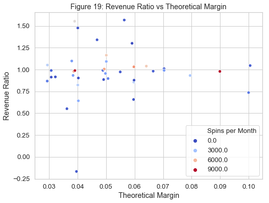

```python
plt.figure(figsize=ncol1)
sns.scatterplot('Theoretical Margin', 'Revenue Ratio', data=df[df['Spins per Month'] < 1e4],
                hue='Spins per Month', palette='coolwarm')
plt.title(fig_counter() + 'Revenue Ratio vs Theoretical Margin');
```

Figure 20 shows distribution of `Revenue Ratio` for each `Theoretical Margin Bin` (one game with a negative `Revenue Ratio` is not shown). The median of each group is similar and no statistical difference is observed as the ANOVA F-statistic p-value of 0.78 is far about the threshold of 0.05.

Therefore, game stability is not effected by `Theoretical Margin`.

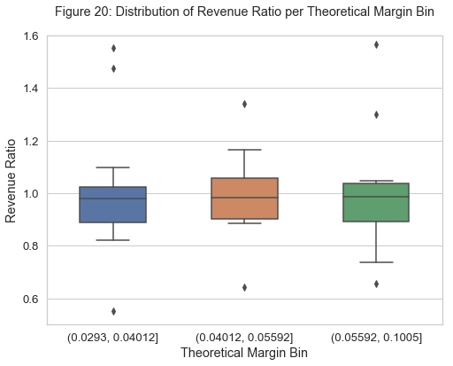

```python
plt.figure(figsize=ncol1)
sns.boxplot('Theoretical Margin Bin', 'Revenue Ratio', data=df, width=0.5)
plt.ylim(0.5, 1.6)
plt.title(fig_counter() + 'Distribution of Revenue Ratio per Theoretical Margin Bin', y=1.05);
```

```python
# ANOVA F-statistic p-value
sm.OLS(df['Revenue Ratio'], sm.add_constant(df_dummy)).fit().f_pvalue.round(2)
```

```
0.78
```